# Project: DATASET INVESTIGATION - [GUN PERMIT DATA ANALYSIS]

[figure not shown]

```python
#ploting shapes on per-gun capital per each state in 2016
x = gun_diff2016["states"]
y = gun_diff2016["gun_per_capital2016"]

gun_diff2016.plot(x="states", y="PopApril2016", kind="bar",title = 'Gun_per_Capital_Per each 2016',figsize=(9,9)).set_ylabel('gun_per_capital2016')
```

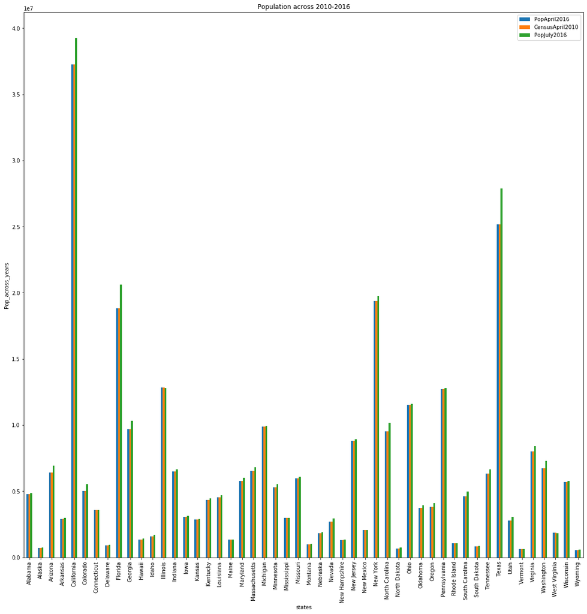

```python
#ploting shapes on populations across years(2010, 2016April and 2016July2016)
gun_diff2016.plot(x="states", y=["PopApril2016", "CensusApril2010", "PopJuly2016"], title = 'Population across 2010-2016', kind="bar",figsize=(19,19)).set_ylabel('Pop_across_years')
```

The above graph depicts population distribution across 2010,2016April and 2016july estimated. It is discover that California state have thelargest population overtime and most population in April 2016population is relative equal or small than the main population census in 2010.

## significant of research question (#comparing 2010 and 2016?)

```python
#sum of total firmarms of all repespectives states in each year divided by the sum total of all populationacross all state for each year

#For 2010

Compare_2010 = gun_diff['totals'].sum()/ gun_diff['CensusApril2010'].sum()

Compare_2010
```

```
0.046439114800989924
```

```python
#comparing 2016
Compare_2016 = gun_diff2016['totals'].sum()/ gun_diff['PopApril2016'].sum()
Compare_2016
```

```
0.0801749358011621
```

```python
#Total amount of firmarms permit in 2010 i 50 states

gun_diff["totals"].sum()
```

```
12914160
```

```python
##Total amount of firmarms permit in 2016 in 50 states
gun_diff2016["totals"].sum()
```

```
24323168
```

```python
##Total population in2010 across 50 state
gun_diff["CensusApril2010"].sum()
```

```
303364079
```

```python
##Total population in 2016 across 50 state
gun_diff["PopApril2016"].sum()
```

```
303376208
```

### Research Question 2 (Visuals and Distribution!)

Histogram showing total firearms per state as at 2010 & 2016. Result shos both are rightly skewed

```python
def show_distribution(dataset, title):
    plt.hist(dataset['totals'], bins=20, alpha=0.5, histtype='stepfilled', color='steelblue', edgecolor='none')

    plt.xlabel('total')
    plt.ylabel('Counts')
    plt.title(title)
```

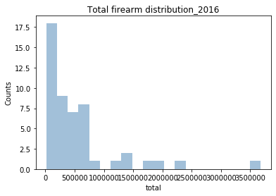

```python
show_distribution(gun_diff2016, 'Total firearm distribution_2016')
```

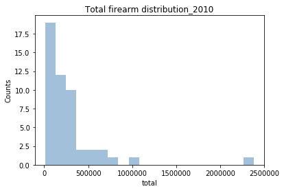

```python
#gun_diff['totals'].hist(bins = 20)

show_distribution(gun_diff, 'Total firearm distribution_2010')
```

## Limitation

.Indepth or granular analyis on types and growth of specific firearms across states is not explore.

.Dataset on firearms didn't provide detail features on population type of each type of Gun permit. e.g Age, Sex, employment, and others specified in the US_population dataset. More information on this data set could have show prediction of other factors that could lead to growth in firearms permit.

.There exist between 5%-10% Nan values and letters instead of number values in some column in the firearm data set.

.The population dataset contains objects and floating values which requires cleaning

.Analysis finding is focus on dataset between 2010 and 2016